# BHMA 1

### Διάβασμα αρχείων

Αποθηκεύω στη μεταβλητή path το path που έχω τα αρχεία train.txt,test.txt

```python
import warnings
warnings.filterwarnings("ignore",category=DeprecationWarning)
warnings.filterwarnings("ignore",category=FutureWarning)
path = '/home/zerkes/Desktop/DSML - MASTER/1st semester/PATTERN RECOGNITION/1 lab ex/pr_lab1_2016-17_data/'
```

Φορτώνω τα ζητούμενα αρχεία με τη χρήση της εντολής numpy.loadtxt, όπου περνάω το path + filename

```python
import numpy as np

train = np.loadtxt(path + 'train.txt')
test =  np.loadtxt(path + 'test.txt')

x_train = train[:, 1::]
y_train = train[:, 0]
x_test = test[:, 1::]
y_test  = test[:, 0]
```

Παρακάτω θα εμφανίσουμε τους πίνακες που δημιουργήσαμε παραπάνω για να δούμε αν πετύχαμε αυτό που θέλουμε.

```python
print(train[:10])
train.shape
```

```
[[ 6.    -1.    -1.    ... -1.    -1.    -1.   ]
 [ 5.    -1.    -1.    ... -0.671 -0.828 -1.   ]
 [ 4.    -1.    -1.    ... -1.    -1.    -1.   ]
 ...
 [ 1.    -1.    -1.    ... -1.    -1.    -1.   ]
 [ 0.    -1.    -1.    ... -1.    -1.    -1.   ]
 [ 1.    -1.    -1.    ... -1.    -1.    -1.   ]]
```

```
(7291, 257)
```

O πίνακας train έχει 7291 samples και 257 στήλες, όπου η 1η όπως βλέπουμε είναι το label και οι άλλες τα features

```python
print(test[:10])
test.shape
```

```
[[ 9. -1. -1. ... -1. -1. -1.]
 [ 6. -1. -1. ... -1. -1. -1.]
 [ 3. -1. -1. ... -1. -1. -1.]
 ...
 [ 0. -1. -1. ... -1. -1. -1.]
 [ 6. -1. -1. ... -1. -1. -1.]
 [ 9. -1. -1. ... -1. -1. -1.]]
```

```
(2007, 257)
```

Παρατηρόυμε πως ο test έχει τα ίδια χαρακτηριστικά με τον train αλλά με αρκετά λιγότερα samples.

Παρακάτω θα εμφανίσουμε τους πίνακες x_train,y_train όπου ο x_train περιέχει τα στοιχεία του train απο τη 2η στήλη ως το τέλος που είναι τα features. Ένω, ο y_train περιέχει μόνο τη 1η στήλη που είναι τα labels.

```python
print(x_train[:5])
print(y_train[:5])
```

```
[[-1.    -1.    -1.    ... -1.    -1.    -1.   ]
 [-1.    -1.    -1.    ... -0.671 -0.828 -1.   ]
 [-1.    -1.    -1.    ... -1.    -1.    -1.   ]
 [-1.    -1.    -1.    ... -1.    -1.    -1.   ]
 [-1.    -1.    -1.    ... -0.883 -1.    -1.   ]]
[6. 5. 4. 7. 3.]
```

Ομοίως και για τους x_test , y_test που εμπεριέχουν με τον ίδιο τρόπο τα στοιχεία του test

```python
print(x_test[:5])
print(y_test[:5])
```

```
[[-1. -1. -1. ... -1. -1. -1.]
 [-1. -1. -1. ... -1. -1. -1.]
 [-1. -1. -1. ... -1. -1. -1.]
 [-1. -1. -1. ... -1. -1. -1.]
 [-1. -1. -1. ... -1. -1. -1.]]
[9. 6. 3. 6. 6.]
```

# ΒΗΜΑ 2

### Σχεδιασμός του x_train[130] με matplotlib

```python
import matplotlib.pyplot as plt
```

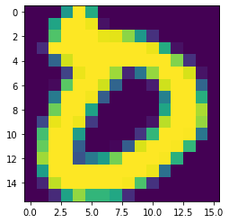

```python
n131 = x_train[130].reshape(16,16)
plt.imshow(n131)
```

# ΒΗΜΑ 3

### Σχεδιασμός από ένα τυχαίο δείγμα 10 αριθμών με τη χρήση του add_subplot

Στο συγκεκριμένο κομμάτι κώδικα , κάνω χρήση της random.choice() για να επιλέξω 10 τυχαίους αριθμούς ως το np.arange(256)=0,1,...255.

Έπειτα κάνω μια λούπα με 10 επαναλήψεις και στην κάθε επανάληψη διαλέγω από τον x_train πίνακα τους αριθμούς για τους οποίους ισχύει ότι είναι ίσοι με το iterator (i) της δομής επανάληψης for.

**tmp = x_train[y_train == i]** Με αυτή την εντοή σώνω στον πίνακα tmp ,τους αριθμούς που περιγράψαμε παραπάνω.

**ax.imshow(tmp[sample_index].reshape(16,16))** . Εδώ από τον πίνακα tmp παίρνω ένα τυχαίο δείγμα με τη χρήση του random_choice() που αναφέραμε πριν.

**ax = fig.add_subplot(5,2,i+1)** Στην εντολή αυτή επιλέγω στο πλέγμα 5χ2 που έχουμε δημιουργήσει σε ποιο subplot θα εμφανιστεί η εικόνα.

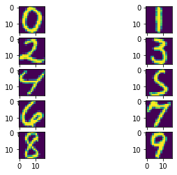

```python
fig = plt.figure()
random_sample = np.random.choice(256,10)
for i in range(10):
    sample_index = random_sample[i]
    ax = fig.add_subplot(5,2,i+1)
    tmp = x_train[y_train == i]
    ax.imshow(tmp[sample_index].reshape(16,16))
```

# ΒΗΜΑ 4

### Υπολογίστε τη μέση τιμή των χαρακτηριστικών του pixel (10, 10) για το ψηφίο «0» με βάση τα train δεδομένα.

Στον πίνακα digit0 που είναι όλα τα δείγματα που αναλογούν στο ψηφίο <<0>> ,καλώ τη συνάρτηση mean για τον υπολογισμό της μέσης τιμής στον άξονα των στηλών και έπειτα διαλέγω τη στήλη που θέλω , δηλαδή την 153 καθώς η κάθε γραμμή εχει 16 στήλες οπότε εφόσον η python αρχίζει τον υπολογισμό από το 0 η ζητούμενη στήλη στο flatten χ_τραιν είναι η 153= 9*16 + 9.

```python
myfeature = (16 * 9) +9
cond = [y_train==0] # mask -> για να διαλέξω τα στοιχεία του x_train που έχουν label στο y_train <<0>>
digit0 = x_train[cond]

print(digit0.mean(axis=0)[myfeature])
```

```
-0.927264656616415
```

# ΒΗΜΑ 5

### Υπολογίστε τη διασπορά των χαρακτηριστικών του pixel (10, 10) για το ψηφίο «0» με βάση τα train δεδομένα.

Στον πίνακα digit0 που είναι όλα τα δείγματα που αναλογούν στο ψηφίο <<0>> ,καλώ τη συνάρτηση var για τον υπολογισμό της διασποράς στον άξονα των στηλών και έπειτα διαλέγω τη στήλη που θέλω , δηλαδή την 153.

```python
print(digit0.var(axis=0)[myfeature])
```

```
0.08392455977261963
```

# ΒΗΜΑ 6

### Υπολογίστε τη μέση τιμή και διασπορά των χαρακτηριστικών κάθε pixel για το ψηφίο «0» με βάση τα train

### δεδομένα.

```python
mean = digit0.mean(axis=0)
print(mean[:10])
```

```
[-0.99862814 -0.99539782 -0.98492295 -0.94125126 -0.83334255 -0.57142295
 -0.13158459  0.15260804  0.04628392 -0.35370101]
```

```python
var = digit0.var(axis=0)
print(var[:10])
```

```
[0.00224522 0.00660664 0.01959062 0.0629012  0.18036652 0.37211377
 0.5316834  0.53820145 0.56258628 0.4576208 ]
```

# ΒΗΜΑ 7

### Σχεδιασμός του 0 με βάση τα Mean values

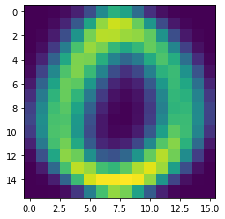

```python
plt.imshow(mean.reshape(16,16))
```

# BHMA 8

### Σχεδιασμός του 0 με βάση τα Variance values

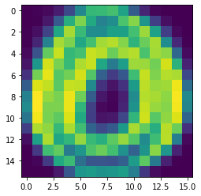

```python
plt.imshow(var.reshape(16,16))
```

Όπως φαίνεται απο την εικόνα με τις μέσες τιμές όπως στο βήμα 7 είναι πιο ξεκάθαρο ότι το ψηφίο ειναι <<0>>. Στην εικόνα του βήματος 8 με τη διασπορά η διαφορά με την προηγούμενη εικόνα είναι πως οι γραμμές γύρο από το κενό είναι αρκετά πιο μεγάλες και μας δείχνει το κατά πόσο ξεφεύγουν από τη μέση τιμή τους. Δηλαδή κάποιος μπορεί να γράψει το <<0>> με μεγαλύτερη περίμετρο της γραμμής ενώ άλλος με μικρότερη.

# ΒΗΜΑ 9

### (a) Υπολογίστε τη μέση τιμή και διασπορά των χαρακτηριστικών για όλα τα ψηφία (0-9) με βάση τα train δεδομένα

### (b) Σχεδιάστε όλα τα ψηφία χρησιμοποιώντας τις τιμές της μέσης τιμής που υπολογίσατε στο Βήμα 9(α).

Θα υλοποιήσουμε μια συνάρτηση για το κάθε ερώτημα

Για το **(α)** φτιάχνω την def statistics(X,y) η οποία υπολογίζει το μέσο και τη διασπορά του κάθε χαρακτηριστικού για το κάθε ψηφίο.

Ο πίνακας για τις μέσες τιμές και τις διασπορές θα ειναι σε θέμα μεγέθους ίδιος , (10,256) , 10 γραμμές λόγω των 10 ψηφίων και 256 γραμμές λόγω των 256 χαρακτηριστικών

Η λογική της συνάρτησης είναι να γίνεται μια επανάληψη όσος και ο αριθμός των label , δηλαδή 10 (0-9) και να βρίσκω σε κάθε επανάληψη με τη χρήση mask στον πίνακα x_train τον αριθμό που είναι ίδιος με τον iterator της λούπας. Για παράδειγμα, αν είμαι στην πρώτη επανάληψη i=0 λόγω της εντολής: **train[condition]** όπου **condition=[y == i]** θα πάρω τα στοιχεία 0 του train κ.ο.κ.

```python
def statistics(X,y):
    variance = np.zeros((10,256))
    mean = np.zeros((10,256))
    for i in range(10):
        condition = [y == i]
        digit = X[condition]
        mean[i] = digit.mean(axis=0)
        variance[i]=digit.var(axis=0)
    return mean,variance
```

```python
mean , variance = statistics(x_train,y_train)
```

```python
print(mean[0,:10])
```

```
[-0.99862814 -0.99539782 -0.98492295 -0.94125126 -0.83334255 -0.57142295
 -0.13158459  0.15260804  0.04628392 -0.35370101]
```

```python
print(variance[0,:10])
```

```
[0.00224522 0.00660664 0.01959062 0.0629012  0.18036652 0.37211377
 0.5316834  0.53820145 0.56258628 0.4576208 ]
```

Στα παραπάνω τυπώσαμε τα 10 πρώτα χαρακτηριστικά για το στοιχείο <<0>> για να τα συγκρίνουμε με αυτά που υπολογίσαμε προηγουμένως. Όπως φαίνεται , είναι ίδια.

Για το **(β)** . Διατρέχω στη συνάρτηση μια λούπα για όσο είναι το μέγεθος των γραμμών του πίνακα mean το οποίο ισούται με τον αριθμό των label. Και σε κάθε λούπα τυπώνω τον αντίστοιχο αριθμό πάνω σε ένα subplot σε grid 5x2

```python
def show_mean_digits(mean):
    fig2 = plt.figure()
    for i in range(mean.shape[0]):
        ax = fig2.add_subplot(5,2,i+1)
        ax.imshow(mean[i,:].reshape(16,16))
```

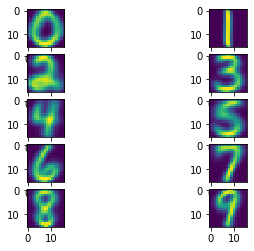

```python
show_mean_digits(mean)
```

# BHMA 10

Για την ταξινόμηση του στοιχείου x_test[100] θα χρησιμοποιήσουμε τις μέσες τιμές που υπολογίσαμε από πριν για τα x_train. Ουσιαστικά θα βρω την ευκλίδεια απόσταση μεταξύ των χαρακτηριστικών του x_test[100] με κάθε μέση τιμή χαρακτηριστικών για το κάθε ψηφίο. Όποιο έχει μικρότερη απόσταση , σε αυτό θα το ταξινομήσουμε

Στη συνέχεια θα τσεκάρω από τον πίνακα y_test αν αυτό που υπολογίσαμε είναι σωστό.

```python
dist = (mean - x_test[100])**2 # (mi - xi)^2 για κάθε χαραητιριστικό
dist = np.sum(dist, axis=1)    # (m1-x1)^2 + ... + (m256-x256)^2
dist = np.sqrt(dist)           # ρίζα όλου του απο πάνω

print("Estimated Number is: " , np.argmin(dist))
if np.argmin(dist) == y_test[100]:              # παίρνουμε το index της μικρότερης τιμής που είναι έχει μικρότερη
    print("Correct Estimation")                 # απόσταση και βλέπουμε αν ισούται με το label στο y_test[100]
else:
    print("Wrong Estimation")
```

```
Estimated Number is:  0
Correct Estimation
```

# BHMA 11

**(α)** Ταξινομήστε όλα τα ψηφία των test δεδομένων σε μία από τις 10 κατηγορίες με βάση την Ευκλείδια απόσταση. **(b)** Υπολογίστε το ποσοστό επιτυχίας για το Βήμα 11(a)

Με την παρακάτω συνάρτηση υπολογίζω τα predictions και ταυτόχρονα το score των predictions αυτών. Διατρέχουμε τον πίνακα με τα δεδομένα για test τον x_test για όλες τις γραμμές του που αντιστοιχούν σε δείγματα αριθμών. Για κάθε τέτοιο αριθμό βρίσκω την ευκλίδεια απόσταση του από το μέσο κάθε ψηφίου και το ταξινομώ σε αυτό που έχει μικρότερη απόσταση.

Έπειτα, τσεκάρουμε αν είναι σωστή η πρόβλεψη και αν είναι αυξάνουμε έναν counter κατά 1. Έτσι ώστε, στο τέλος να βγάλουμε το ποσοστό επι τοις εκατό που θέλουμε.

```python
def eucl_dist_est(x,y,mu):
    counter = 0
    predictions=[]
    for i in range(x.shape[0]):
        dist = np.sqrt(np.sum((mean-x[i])**2,axis=1)) # υπολογισμός αποστάσεων
        if np.argmin(dist) == y[i]: # τσεκαρουμε αν είναι σωστή η πρόβλεψη
            counter += 1
        predictions.append(np.argmin(dist))
    success_score = (counter/ x.shape[0]) * 100

    return predictions, success_score
```

```python
pred,scr = eucl_dist_est(x_test,y_test,mean)
print(scr)
```

```
81.41504733432984
```

# ΒΗΜΑ 12

- Παρακάτω φαίνεται ο υλοποιημένος κώδικας σε scikit-learn estimator.
- Στη συνάρτηση init , θέτουμε το self.X*mean* = None.
- To trailing underscore δεν είναι τίποτα παραπάνω από το να καταλαβαίνουμε ότι οι μεταβλητές αυτές αναφέρονται στο scope του class.
- Στη μέθοδο fit γίνεται το training του estimator μας, καθώς εκέι μαθαίνει τον πίνακα self.X*mean* πάνω στον οποίο θα βασίζονται οι ταξινομήσεις μετά.
- Ο αλγόριθμος του fit βασίζεται στη λογική του βήματος 9 που υπολόγισα για κάθε ψηφίο το mean value του. Δηλαδή πάλι αρχικοποιώ το self.X*mean* με 0 και μέγεθος (labels,X.shape[1]) όπου X.shape[1] είναι ο αριθμός στηλών του train dataset και το labels είναι ο αριθμός των κλάσεων που βρίσκει από το σημείο του κώδικα labels = len(set(y.tolist())).
- Στη συνέχεια, τρέχω μια λούπα για κάθε class και με τη χρήση mask στο πινακα X κρατάω το ψηφίο για το οποίο θέλω να υπολογίσω τις μέσες τιμές του.
- Ο αλγόριθμος της συνάρτησης predict είναι αντίστοιχος του βήματος (11α) .
- Ενώ της συνάρτησης scorer είναι αντίστοιχος του βήματος (11β).

```python
from sklearn.base import BaseEstimator, ClassifierMixin
import numpy as np
class EuclideanClassifier(BaseEstimator, ClassifierMixin):
    """Classify samples based on the distance from the mean feature value"""

    def __init__(self):
        self.X_mean_ = None
        #self.label_number_ = label_number


    def fit(self, X, y):
        """
        This should fit classifier. All the "work" should be done here.

        Calculates self.X_mean_ based on the mean
        feature values in X for each class.

        self.X_mean_ becomes a numpy.ndarray of shape
        (n_classes, n_features)

        fit always returns self.
        """
        labels = len(set(y.tolist()))
        self.X_mean_ = np.zeros((labels,X.shape[1]))
        for i in range(labels):
            condition = [y == i]
            digit = X[condition]
            self.X_mean_[i] = digit.mean(axis=0)

        return self


    def predict(self, X):
        """
        Make predictions for X based on the
        euclidean distance from self.X_mean_
        """
        predictions=[]
        for i in range(X.shape[0]):
            dist = np.sqrt(np.sum((self.X_mean_-X[i])**2,axis=1))
            predictions.append(np.argmin(dist))

        return np.asarray(predictions)

    def scorer(self, X, y):
        """
        Return accuracy score on the predictions
        for X based on ground truth y
        """
        acc_arr = (X == y)
        return (np.sum(acc_arr) / X.shape[0]) * 100
```

```python
model = EuclideanClassifier()

model.fit(x_train,y_train)

predictions_from_myest = model.predict(x_test)

score_from_myest = model.scorer(predictions_from_myest,y_test)

print(score_from_myest)
```

```
81.41504733432984
```

Όπως φαίνεται πήραμε το ίδιο αποτέλεσμα με πριν.

# ΒΗΜΑ 13

### α) Υπολογίστε το score του ευκλείδιου ταξινομητή με χρήση 5-fold cross-validation

### β) Σχεδιάστε την περιοχή απόφασης του ευκλείδιου ταξινομητή.

### γ) Σχεδιάστε την καμπύλη εκμάθησης του ευκλείδιου ταξινομητή (γραμμένα στο χέρι σεlearning curve)

Για το **(α)**

```python
from sklearn.model_selection import cross_val_score
full_dataset = np.concatenate((train,test),axis=0) # ενώνω τα train,test σαν ένα dataset
x_full = full_dataset[:,1::]                       # βάζω τα features στον χ_full
y_full = full_dataset[:,0]                         # τα labels στον y_full
print(cross_val_score(EuclideanClassifier(), x_full, y_full, cv=5).mean())
```

```
0.841773724173982
```

Για το **(b)**

```python
def plot_clf(clf, X, y, labels):
    fig, ax = plt.subplots()
    # title for the plots
    title = ('Decision surface of Classifier')
    # Set-up grid for plotting.
    X0, X1 = X[:, 0], X[:, 1]

    x_min, x_max = X0.min() - 1, X0.max() + 1
    y_min, y_max = X1.min() - 1, X1.max() + 1
    xx, yy = np.meshgrid(np.arange(x_min, x_max, .05),
                         np.arange(y_min, y_max, .05))

    Z = clf.predict(np.c_[xx.ravel(), yy.ravel()])
    Z = Z.reshape(xx.shape)
    out = ax.contourf(xx, yy, Z, cmap=plt.cm.coolwarm, alpha=0.8)

    zeros = ax.scatter(
        X0[y == 0], X1[y == 0],
        c='blue', label=labels[0],
        s=60, alpha=0.9, edgecolors='k')
    ones = ax.scatter(
        X0[y == 1], X1[y == 1],
        c='red', label=labels[1],
        s=60, alpha=0.9, edgecolors='k')
    twos = ax.scatter(
        X0[y == 2], X1[y == 2],
        c='yellow', label=labels[2],
        s=60, alpha=0.9, edgecolors='k')
    threes = ax.scatter(
        X0[y == 3], X1[y == 3],
        c='pink', label=labels[3],
        s=60, alpha=0.9, edgecolors='k')
    fours = ax.scatter(
        X0[y == 4], X1[y == 4],
        c='olive', label=labels[4],
        s=60, alpha=0.9, edgecolors='k')
    fives = ax.scatter(
        X0[y == 5], X1[y == 5],
        c='yellow', label=labels[5],
        s=60, alpha=0.9, edgecolors='k')
    sixs = ax.scatter(
        X0[y == 6], X1[y == 6],
        c='purple', label=labels[6],
        s=60, alpha=0.9, edgecolors='k')
    sevens = ax.scatter(
        X0[y == 7], X1[y == 7],
        c='green', label=labels[7],
        s=60, alpha=0.9, edgecolors='k')
    eights = ax.scatter(
        X0[y == 8], X1[y == 8],
        c='orange', label=labels[8],
        s=60, alpha=0.9, edgecolors='k')
    nines = ax.scatter(
        X0[y == 9], X1[y == 9],
        c='brown', label=labels[9],
        s=60, alpha=0.9, edgecolors='k')

    ax.set_ylabel(labels[1])
    ax.set_xlabel(labels[0])
    ax.set_xticks(())
    ax.set_yticks(())
    ax.set_title(title)
    ax.legend()
    plt.show()
```

Παίρνω ενα διάνυσμα με 2d array features για να μπορώ να το αναπαραστήσω σε 2d array διαστάσεις και φτιάχνω ένα νέο model του ταξινομητή μου, το οποίο είναι εκπαιδευμένο για 2d array features. Έπειτα, στην σύναρτηση, που θα βγάλει το decision surface περνάω το καινούριο μοντέλο μου, το νεο x_new το y_full κανονικά και έπειτα περνάω τα target_names που είναι οι αριθμοί απο 0-9 που αντιστοιχούν και στα classes του προβλήματος μας.

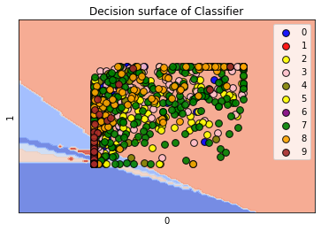

```python
x_new = x_full[:,2:4]
model_new = EuclideanClassifier()
model_new.fit(x_new ,y_full)

plot_clf(model_new, x_new , y_full, ['0','1','2' , '3','4','5','6','7','8','9'])
```

Το παραπάνω decision surface έγινε με τυχαία επιλογή χαρακτηριστικών. Τώρα θα δοκιμάσουμε κάτι άλλο. Να επιλέξουμε τα χαρακτηριστικά με βάση τον αλγόριθμο PCA.

### Χρήση PCA

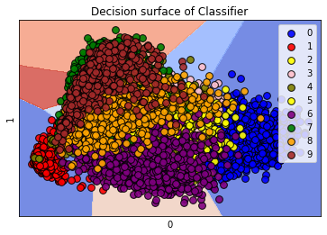

```python
#using pca
from sklearn.decomposition import PCA
x_pca = x_full # temp variable for pca only
pca = PCA(n_components=2)
pca.fit(x_pca)
x_pca = pca.transform(x_pca)

model_pca = EuclideanClassifier()
model_pca.fit(x_pca ,y_full)
plot_clf(model_pca, x_pca , y_full, ['0','1','2' , '3','4','5','6','7','8','9'])
```

Για το **(γ)**

```python
def plot_learning_curve(train_scores, test_scores, train_sizes, ylim=(0, 1)):
    plt.figure(5, figsize=(4,4))
    plt.title("Learning Curve")
    if ylim is not None:
        plt.ylim(*ylim)
    plt.xlabel("Training examples")
    plt.ylabel("Score")

    train_scores_mean = np.mean(train_scores, axis=1)
    train_scores_std = np.std(train_scores, axis=1)
    test_scores_mean = np.mean(test_scores, axis=1)
    test_scores_std = np.std(test_scores, axis=1)
    plt.grid()

    plt.fill_between(train_sizes, train_scores_mean - train_scores_std,
                     train_scores_mean + train_scores_std, alpha=0.1,
                     color="r")
    plt.fill_between(train_sizes, test_scores_mean - test_scores_std,
                     test_scores_mean + test_scores_std, alpha=0.1, color="g")
    plt.plot(train_sizes, train_scores_mean, 'o-', color="r",
             label="Training score")
    plt.plot(train_sizes, test_scores_mean, 'o-', color="g",
             label="Cross-validation score")

    plt.legend(loc="best")
    return plt
```

```python
from sklearn.model_selection import learning_curve
train_sizes, train_scores, test_scores = learning_curve(EuclideanClassifier(),
                                                        x_full, y_full, cv=5,
                                                        train_sizes=np.linspace(0.15, 1.0, 5))
```

[output not shown]

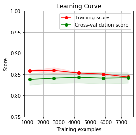

```python
plot_learning_curve(train_scores, test_scores, train_sizes, ylim=(.75, 1))
```